# Homework 5 - Bayes’ Rule with the Example of Volcanic Eruptions

Martina Rosskopf & Nina Golombek

5.12.2018

## Task

```r
erup <- c(50, 89, 77, 103, 70, 45, 63, 99, 67, 81)                          # Nr. of eruptions per year
prior_lambda <- 1:150
prior_prob <- rep(1 / length(prior_lambda), length(prior_lambda))
```

The following plot shows the probability of eruptions if we have no knowledge about previous years.

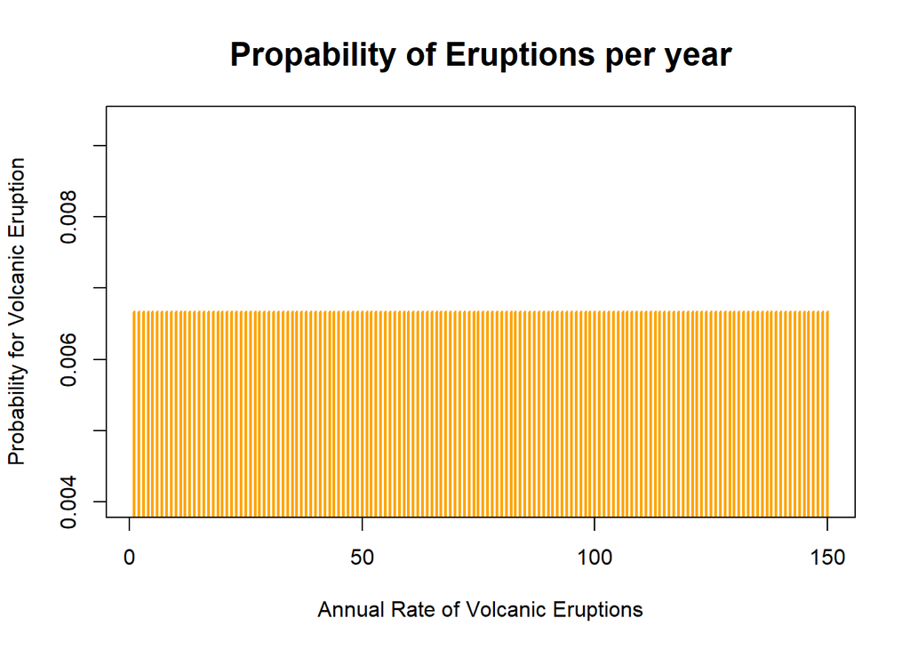

```r
plot(prior_prob, type = "h", lwd = "2",  col = "orange",
     main = "Propability of Eruptions per year",
     xlab = "Annual Rate of Volcanic Eruptions",
     ylab = "Probability for Volcanic Eruption",
     cex.lab = 1, cex.main = 1.5)
```

In the next step we would like to show the likelihood for such an event. First we define a vector **likeli** that has the length of the **prior_lambda** vector, in our case 150. By going from 1 to 150 we calculate the likelihood for each number which represents the amount of eruptions per year.

```r
likeli <- rep(NA, length(prior_lambda))
for (i in 1:length(prior_lambda)){
  likeli[i] <- prod(dpois(erup, i))
}
```

After those calculations we can plot the likelihood agains the amount of eruptions.

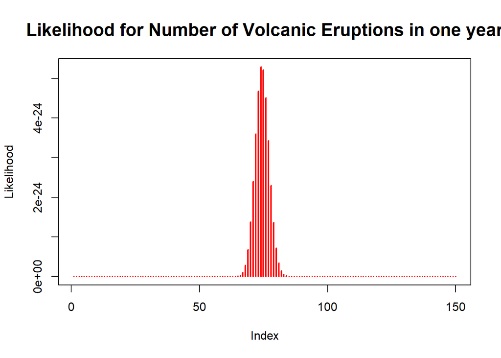

```r
plot(prior_lambda, likeli, type = "h", lwd = "2",  col = "red",
     main = "Likelihood for Number of Volcanic Eruptions in one year",
     xlab = "Index",
     ylab = "Likelihood",
     cex.lab = 1, cex.main = 1.5)
```

Now we want to calculate the posterior for our case which can be done by the following code:

First we multiply the likelihood with the evidences of each possibility. After that we re-normalize them and plot them against the possible annual rates. This gives us a final distribution of our problem related to the given eruptions for ten independent years.

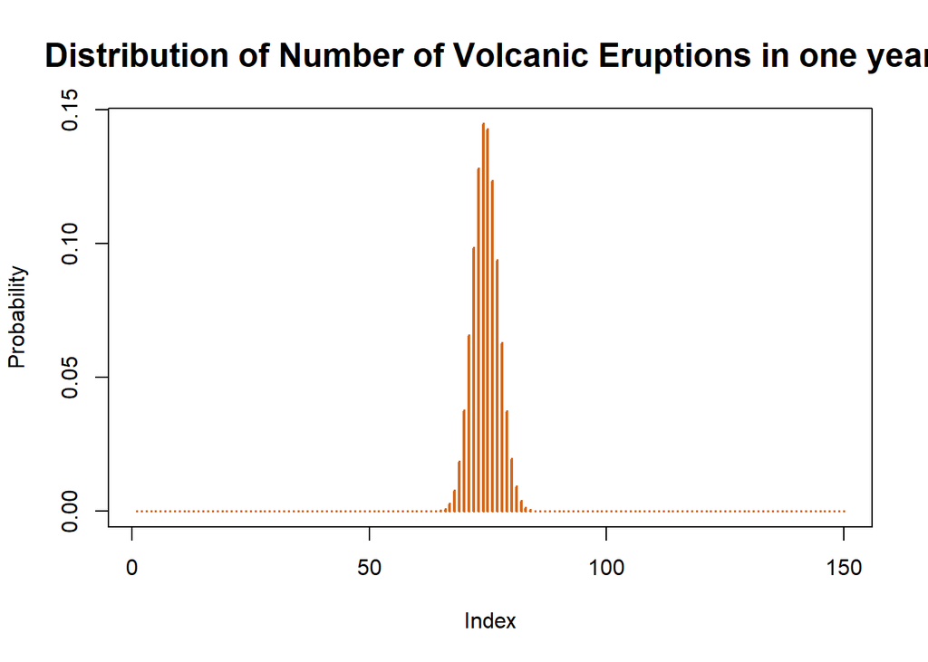

```r
posterior <- likeli * prior_prob
posterior <- posterior / sum(posterior)
plot(prior_lambda, posterior, type = "h", lwd = "2",  col = "chocolate",
     main = "Distribution of Number of Volcanic Eruptions in one year",
     xlab = "Index",
     ylab = "Probability",
     cex.lab = 1, cex.main = 1.5)
```

## Other solution found during the class

We also tried to develope a different approach in class (which seems to have some kind of error since the result differs from the one above).

We definded a matrix **like** with the dimensions of our **erup** vector and **prior_lambda** and fill it with empty values (NA). Than we generated a for-loop that writes all values into the matrix.

```r
like <- matrix(NA, length(erup), length(prior_lambda))
for (i in 1:length(erup)){
  like[i,] <- dpois(prior_lambda, erup[i])
}
```

Ultimatly we plot the collumns of our **like** matrix and multiply each entry.

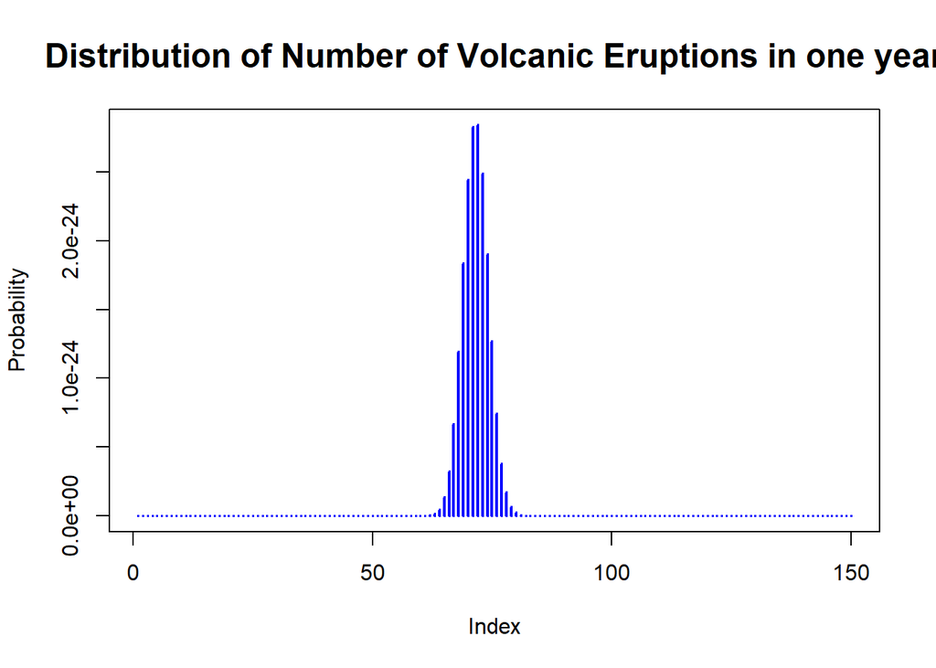

```r
plot(apply(like, 2, prod), type ="h", lwd = "2",  col = "blue",
     main = "Distribution of Number of Volcanic Eruptions in one year",
     xlab = "Index",
     ylab = "Probability",
     cex.lab = 1, cex.main = 1.5)
```

We think that this result should give us the likelihood of the different possibilities, but it differs from the one above. It also can’t be the posterior because the sum is not 1 and we haven’t done anything with the **prior_prob** yet.